# Statistical Learning

Chapter 3 - Exercise 10

> This questions should be answered using the Carseats data set.

```r
car_seats <- ISLR::Carseats
```

```r
SmartEDA::ExpData(car_seats, type = 1)
```

```
                                          Descriptions     Value
1                                   Sample size (nrow)       400
2                              No. of variables (ncol)        11
3                    No. of numeric/interger variables         8
4                              No. of factor variables         3
5                                No. of text variables         0
6                             No. of logical variables         0
7                          No. of identifier variables         0
8                                No. of date variables         0
9             No. of zero variance variables (uniform)         0
10               %. of variables having complete cases 100% (11)
11   %. of variables having >0% and <50% missing cases    0% (0)
12 %. of variables having >=50% and <90% missing cases    0% (0)
13          %. of variables having >=90% missing cases    0% (0)
```

```r
SmartEDA::ExpData(car_seats, type = 2)
```

```
   Index Variable_Name Variable_Type Per_of_Missing No_of_distinct_values
1      1         Sales       numeric              0                   336
2      2     CompPrice       numeric              0                    73
3      3        Income       numeric              0                    98
4      4   Advertising       numeric              0                    28
5      5    Population       numeric              0                   275
6      6         Price       numeric              0                   101
7      7     ShelveLoc        factor              0                     3
8      8           Age       numeric              0                    56
9      9     Education       numeric              0                     9
10    10         Urban        factor              0                     2
11    11            US        factor              0                     2
```

```r
base::table(car_seats$Education)
```

```
10 11 12 13 14 15 16 17 18
48 48 49 43 40 36 47 49 40
```

## Part a

> Fit a multiple regression model to predict Sales using Price, Urban, and US.

```r
model1_fit <- stats::lm(Sales ~ Price + Urban + US, data = car_seats)
```

```r
base::summary(model1_fit)
```

```
Call:
stats::lm(formula = Sales ~ Price + Urban + US, data = car_seats)

Residuals:
    Min      1Q  Median      3Q     Max
-6.9206 -1.6220 -0.0564  1.5786  7.0581

Coefficients:
             Estimate Std. Error t value Pr(>|t|)
(Intercept) 13.043469   0.651012  20.036  < 2e-16 ***
Price       -0.054459   0.005242 -10.389  < 2e-16 ***
UrbanYes    -0.021916   0.271650  -0.081    0.936
USYes        1.200573   0.259042   4.635 4.86e-06 ***
---
Signif. codes:  0 '***' 0.001 '**' 0.01 '*' 0.05 '.' 0.1 ' ' 1

Residual standard error: 2.472 on 396 degrees of freedom
Multiple R-squared:  0.2393,    Adjusted R-squared:  0.2335
F-statistic: 41.52 on 3 and 396 DF,  p-value: < 2.2e-16
```

## Part b

> Provide an interpretation of each coefficient in the model.

```r
var_price <- if(stats::coef(model1_fit)[["Price"]] < 0) "drop" else "raise"
```

- `Price` = -0.0544588 indicates that sales will drop, on average, by 54 units for every one dollar increase in their price (when holding `Urban` and `US` constant).

```r
var_urbanyes <- if(stats::coef(model1_fit)[["UrbanYes"]] < 0) "lower" else "higher"
```

- `UrbanYes` = -0.0219162 indicates that sales are, on average, 22 units lower for stores in urban areas, compared to stores in non-Urban areas (when holding `Price` and `US` constant).

```r
var_usyes <- if(stats::coef(model1_fit)[["USYes"]] < 0) "lower" else "higher"
```

[output not shown]

## Part c

> Write out the model in equation form, being careful to handle the qualitative variables properly.

$$Sales = 13.04 - 0.05 * Price - 0.02 * \text{I}_{(Urban = Yes)} + 1.2 * \text{I}_{(US = Yes)}$$

## Part d

> For which of the predictors can you reject the null hypothesis $H_0: \beta_j = 0$

Based on *p-vales* for `Price` and `US`.

## Part e

> On the basis of your response to the previous question, fit a smaller model that only uses the predictors for which there is evidence of association with the outcome.

```r
model2_fit <- stats::lm(Sales ~ Price + US, data = car_seats)
```

```r
base::summary(model2_fit)
```

```
Call:
stats::lm(formula = Sales ~ Price + US, data = car_seats)

Residuals:
    Min      1Q  Median      3Q     Max
-6.9269 -1.6286 -0.0574  1.5766  7.0515

Coefficients:
            Estimate Std. Error t value Pr(>|t|)
(Intercept) 13.03079    0.63098  20.652  < 2e-16 ***
Price       -0.05448    0.00523 -10.416  < 2e-16 ***
USYes        1.19964    0.25846   4.641 4.71e-06 ***
---
Signif. codes:  0 '***' 0.001 '**' 0.01 '*' 0.05 '.' 0.1 ' ' 1

Residual standard error: 2.469 on 397 degrees of freedom
Multiple R-squared:  0.2393,    Adjusted R-squared:  0.2354
F-statistic: 62.43 on 2 and 397 DF,  p-value: < 2.2e-16
```

## Part f

> How well do the models in (a) and (e) fit the data?

## Part g

> Using the model from (e), obtain 95% confidence intervals for the coefficient(s).

```r
stats::confint(model2_fit)
```

```
                  2.5 %      97.5 %
(Intercept) 11.79032020 14.27126531
Price       -0.06475984 -0.04419543
USYes        0.69151957  1.70776632
```

## Part h

> Is there evidence of outliers or high leverage observations in the model from (e)?

```r
model2_fit_diagnose <- lindia::gg_diagnose(
  fitted.lm = model2_fit,
  plot.all = FALSE
)
```

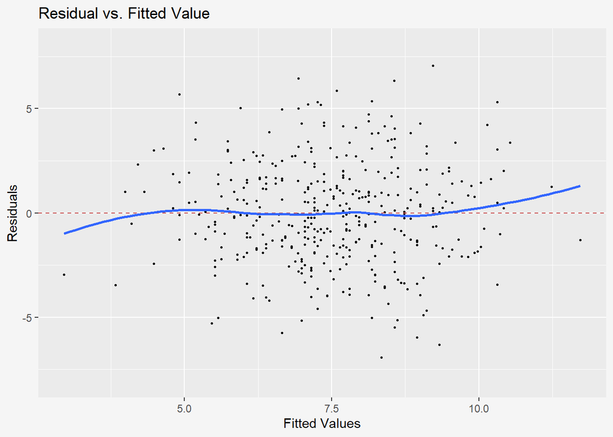

```r
model2_fit_diagnose$res_fitted +
  ggplot2::geom_smooth(
    se = FALSE
  ) +
  ggplot2::theme(
    plot.background = ggplot2::element_rect(
      fill = "#F5F5F5",
      color = "#F5F5F5"
    )
  )
```

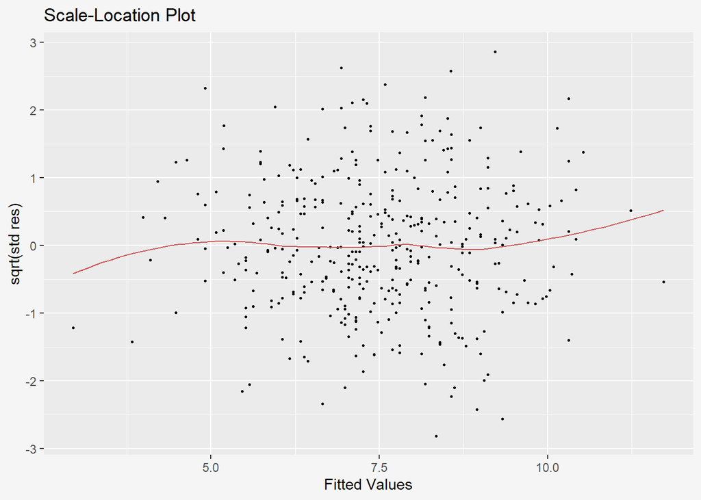

```r
model2_fit_diagnose$scalelocation +
  ggplot2::labs(
    x = "Fitted Values",
    y = "sqrt(std res)"
  ) +
  ggplot2::theme(
    plot.background = ggplot2::element_rect(
      fill = "#F5F5F5",
      color = "#F5F5F5"
    )
  )
```

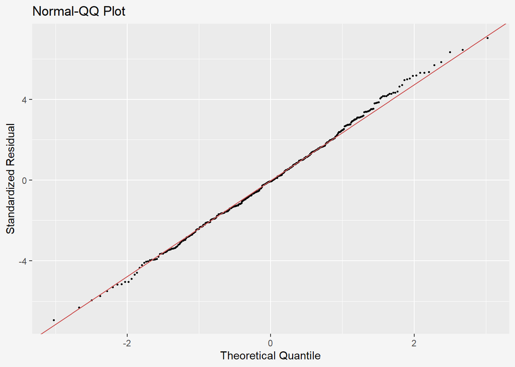

```r
model2_fit_diagnose$qqplot +
  ggplot2::theme(
    plot.background = ggplot2::element_rect(
      fill = "#F5F5F5",
      color = "#F5F5F5"
    )
  )
```

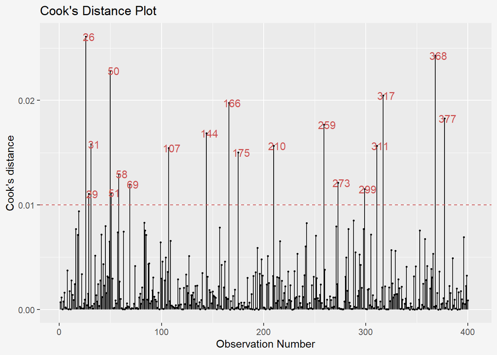

```r
model2_fit_diagnose$cooksd +
  ggplot2::theme(
    plot.background = ggplot2::element_rect(
      fill = "#F5F5F5",
      color = "#F5F5F5"
    )
  )
```

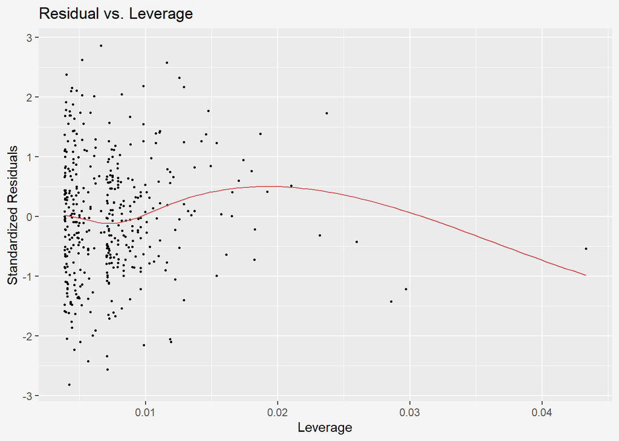

```r
model2_fit_diagnose$resleverage +
  ggplot2::theme(
    plot.background = ggplot2::element_rect(
      fill = "#F5F5F5",
      color = "#F5F5F5"
    )
  )
```